# Case_Study_2

JSaldana_CaseStudy2

December 3, 2018

Questions of Interest: What are (at least) the top 3 factors that contribute to attrition?

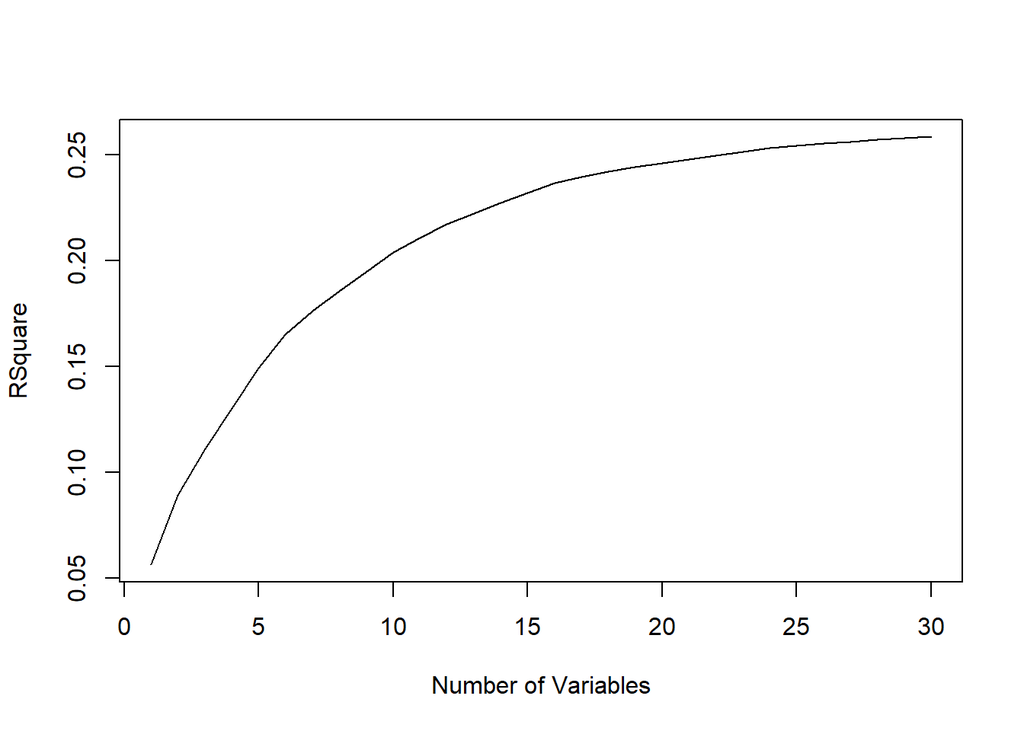

```r
#Code Attrition to Yes = 1 and No = 0
dfTrain$Attrition <- ifelse(dfTrain$Attrition == "Yes", 1, ifelse(dfTrain$Attrition == "No", 0, 99))

#Cancel out variables w/ only 1 level or that are irrelevant/redundant
dfTrain$ID <- NULL
dfTrain$EmployeeCount <- NULL
dfTrain$EmployeeNumber <- NULL
dfTrain$Over18 <- NULL
dfTrain$StandardHours <- NULL
dfTrain$Rand <- NULL

#This leaves 31 variables, 1 of which is the dependent
regfit.full = regsubsets(Attrition~., dfTrain, nvmax = 30)
reg.summary <- summary(regfit.full)
plot(reg.summary$rsq,xlab = "Number of Variables", ylab = "RSquare", type = "l")
```

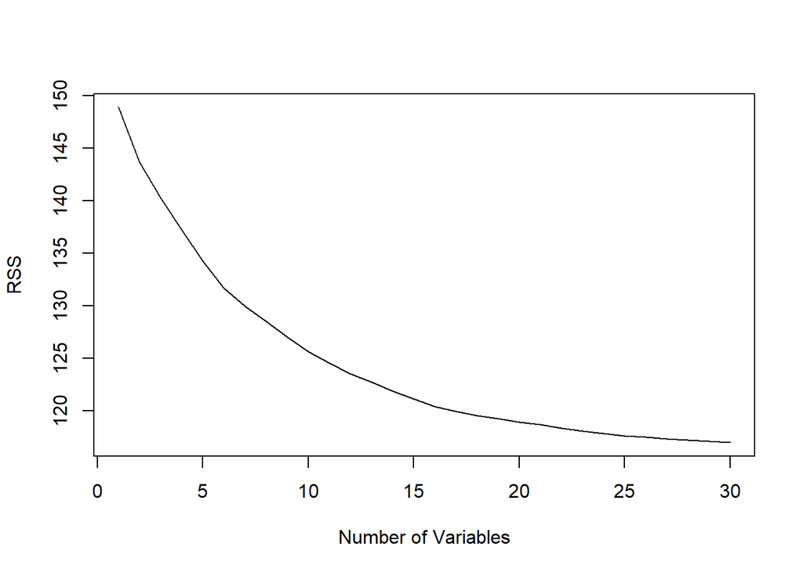

```r
plot(reg.summary$rss,xlab = "Number of Variables", ylab = "RSS", type = "l")
```

### Variable Selection

In the plots above for R-Squared and Sum of Squared Redsiduals, we can see that as we add variables, the model begins to get more accurate but then levels off. We want to develop the most efficient and effective model possible.

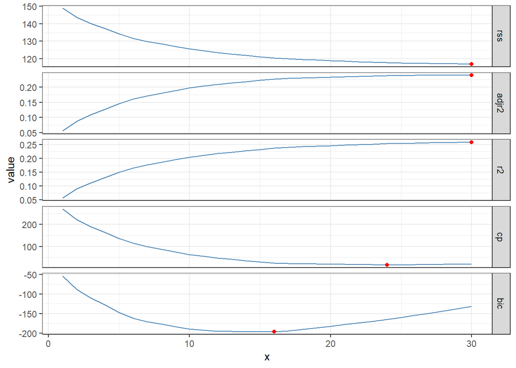

```r
## get best performing models according to each measure
ind.rss <- which.min(reg.summary$rss)
val.rss <- reg.summary$rss[ind.rss]
ind.adjr2 <- which.max(reg.summary$adjr2)
val.adjr2 <- reg.summary$adjr2[ind.adjr2]
ind.r2 <- which.max(reg.summary$rsq)
val.r2 <- reg.summary$rsq[ind.r2]
ind.cp <- which.min(reg.summary$cp)
val.cp <- reg.summary$cp[ind.cp]
ind.bic <- which.min(reg.summary$bic)
val.bic <- reg.summary$bic[ind.bic]


fit.models <- data.frame(x = 1:30, rss = reg.summary$rss, adjr2 = reg.summary$adjr2,
                         r2 = reg.summary$rsq, cp = reg.summary$cp, bic = reg.summary$bic)
fit.models <- melt(fit.models, id.vars = 'x')

best.vals  <- data.frame(variable = unique(fit.models$variable),
                         inds = c(ind.rss, ind.adjr2, ind.r2, ind.cp, ind.bic),
                         vals = c(val.rss, val.adjr2, val.r2, val.cp, val.bic))

ggplot(data = fit.models, aes(x = x, y = value)) + geom_line(color = 'steelblue') +
  geom_point(data = best.vals, aes(x = inds, y = vals),color = 'red') +
  facet_grid(variable ~., scales="free_y") + theme_bw()
```

```r
#Selected Variables
coef(regfit.full,16)
```

```
##                      (Intercept)  BusinessTravelTravel_Frequently
##                      0.584598194                      0.092699911
## DepartmentResearch & Development                 DistanceFromHome
##                     -0.067240199                      0.003115530
##   EducationFieldTechnical Degree          EnvironmentSatisfaction
##                      0.097136364                     -0.047619899
##                   JobInvolvement     JobRoleLaboratory Technician
##                     -0.067607537                      0.117927789
##      JobRoleSales Representative                  JobSatisfaction
##                      0.163516509                     -0.034551808
##              MaritalStatusSingle               NumCompaniesWorked
##                      0.118131831                      0.014898950
##                      OverTimeYes                TotalWorkingYears
##                      0.205476320                     -0.005811711
##                  WorkLifeBalance               YearsInCurrentRole
##                     -0.043045583                     -0.009216888
##          YearsSinceLastPromotion
##                      0.014179149
```

Using the same plot as before, we can see that 7 is also a good number to use where BIC curve begins.

```r
#narrow down to 7
coef(regfit.full,7)
```

```
##                  (Intercept)      EnvironmentSatisfaction
##                   0.44483976                  -0.04784939
##               JobInvolvement JobRoleLaboratory Technician
##                  -0.07073365                   0.11935710
##  JobRoleSales Representative              JobSatisfaction
##                   0.25327615                  -0.03519102
##          MaritalStatusSingle                  OverTimeYes
##                   0.12659351                   0.20850031
```

Now we turn to the 3 most impactful vairables.

```r
#narrow down to 3
coef(regfit.full,3)
```

```
##                 (Intercept) JobRoleSales Representative
##                   0.0481313                   0.2373475
##         MaritalStatusSingle                 OverTimeYes
##                   0.1352584                   0.1956325
```

With these results, we can beging to build a model to see whether 16, 7, or 3 variables is the most accurate and efficient.

### Build and compare 3 models

```r
#build the model
lm1 = glm(Attrition ~ Department + EducationField + JobRole + MaritalStatus + OverTime + BusinessTravel + DistanceFromHome +EnvironmentSatisfaction + JobInvolvement + JobLevel + NumCompaniesWorked + TotalWorkingYears + YearsInCurrentRole, data = dfTrain, family = binomial(link = 'logit'))

#View results
summary(lm1)
```

```
##
## Call:
## glm(formula = Attrition ~ Department + EducationField + JobRole +
##     MaritalStatus + OverTime + BusinessTravel + DistanceFromHome +
##     EnvironmentSatisfaction + JobInvolvement + JobLevel + NumCompaniesWorked +
##     TotalWorkingYears + YearsInCurrentRole, family = binomial(link = "logit"),
##     data = dfTrain)
##
## Deviance Residuals:
##     Min       1Q   Median       3Q      Max
## -1.7576  -0.5306  -0.3251  -0.1468   3.3071
##
## Coefficients:
##                                   Estimate Std. Error z value Pr(>|z|)
## (Intercept)                      -14.46045  463.49653  -0.031 0.975111
## DepartmentResearch & Development  12.71709  463.49561   0.027 0.978111
## DepartmentSales                   11.71578  463.49638   0.025 0.979834
## EducationFieldLife Sciences       -0.29559    1.10464  -0.268 0.789016
## EducationFieldMarketing           -0.04461    1.14876  -0.039 0.969022
## EducationFieldMedical             -0.35242    1.11272  -0.317 0.751457
## EducationFieldOther               -0.73828    1.17537  -0.628 0.529920
## EducationFieldTechnical Degree     0.54233    1.12161   0.484 0.628717
## JobRoleHuman Resources            13.36496  463.49582   0.029 0.976996
## JobRoleLaboratory Technician       1.14373    0.47395   2.413 0.015814 *
## JobRoleManager                     0.42510    0.80167   0.530 0.595925
## JobRoleManufacturing Director     -0.40314    0.54275  -0.743 0.457616
## JobRoleResearch Director          -2.01492    1.13597  -1.774 0.076106 .
## JobRoleResearch Scientist          0.14156    0.49006   0.289 0.772692
## JobRoleSales Executive             1.55874    1.31238   1.188 0.234944
## JobRoleSales Representative        2.55338    1.34510   1.898 0.057658 .
## MaritalStatusMarried               0.57319    0.29086   1.971 0.048766 *
## MaritalStatusSingle                1.38460    0.29065   4.764 1.90e-06 ***
## OverTimeYes                        1.69650    0.19800   8.568  < 2e-16 ***
## BusinessTravelTravel_Frequently    1.46310    0.42579   3.436 0.000590 ***
## BusinessTravelTravel_Rarely        0.71356    0.39568   1.803 0.071327 .
## DistanceFromHome                   0.03335    0.01113   2.998 0.002720 **
## EnvironmentSatisfaction           -0.41656    0.08736  -4.768 1.86e-06 ***
## JobInvolvement                    -0.62331    0.12968  -4.806 1.54e-06 ***
## JobLevel                           0.08896    0.23036   0.386 0.699345
## NumCompaniesWorked                 0.14001    0.03912   3.579 0.000345 ***
## TotalWorkingYears                 -0.04796    0.02485  -1.930 0.053604 .
## YearsInCurrentRole                -0.03747    0.03483  -1.076 0.282009
## ---
## Signif. codes:  0 '***' 0.001 '**' 0.01 '*' 0.05 '.' 0.1 ' ' 1
##
## (Dispersion parameter for binomial family taken to be 1)
##
##     Null deviance: 1031.48  on 1169  degrees of freedom
## Residual deviance:  758.68  on 1142  degrees of freedom
## AIC: 814.68
##
## Number of Fisher Scoring iterations: 14
```

```r
#get predictions
dfPreds1 <- predict(lm1, type = "response", newdata = subset(dfVal, select = c("Department", "EducationField", "JobRole", "MaritalStatus", "OverTime", "BusinessTravel", "DistanceFromHome", "EnvironmentSatisfaction", "JobInvolvement", "JobLevel", "NumCompaniesWorked", "TotalWorkingYears", "YearsInCurrentRole")))

#test the model's accuracy
new.preds1 <-ifelse(dfPreds1 > 0.5, "Yes", "No")
misClasificError1 <- mean(new.preds1 != dfVal$Attrition)
print(paste('Accuracy',1-misClasificError1))
```

```
## [1] "Accuracy 0.86"
```

```r
#build the model
lm2 = glm(Attrition ~ JobRole + MaritalStatus + OverTime + BusinessTravel + DistanceFromHome + EnvironmentSatisfaction + JobInvolvement + NumCompaniesWorked, data = dfTrain, family = binomial(link = 'logit'))

#view results
summary(lm2)
```

```
##
## Call:
## glm(formula = Attrition ~ JobRole + MaritalStatus + OverTime +
##     BusinessTravel + DistanceFromHome + EnvironmentSatisfaction +
##     JobInvolvement + NumCompaniesWorked, family = binomial(link = "logit"),
##     data = dfTrain)
##
## Deviance Residuals:
##     Min       1Q   Median       3Q      Max
## -1.7547  -0.5405  -0.3401  -0.1558   3.3861
##
## Coefficients:
##                                 Estimate Std. Error z value Pr(>|z|)
## (Intercept)                     -2.49597    0.69257  -3.604 0.000313 ***
## JobRoleHuman Resources           0.97676    0.61113   1.598 0.109981
## JobRoleLaboratory Technician     1.31451    0.41245   3.187 0.001437 **
## JobRoleManager                  -0.35245    0.64474  -0.547 0.584620
## JobRoleManufacturing Director   -0.38579    0.53568  -0.720 0.471409
## JobRoleResearch Director        -2.31908    1.10981  -2.090 0.036653 *
## JobRoleResearch Scientist        0.36252    0.42428   0.854 0.392867
## JobRoleSales Executive           0.74216    0.41174   1.802 0.071467 .
## JobRoleSales Representative      2.02642    0.47376   4.277 1.89e-05 ***
## MaritalStatusMarried             0.57262    0.28709   1.995 0.046094 *
## MaritalStatusSingle              1.40796    0.28597   4.923 8.51e-07 ***
## OverTimeYes                      1.64214    0.19332   8.494  < 2e-16 ***
## BusinessTravelTravel_Frequently  1.37531    0.41625   3.304 0.000953 ***
## BusinessTravelTravel_Rarely      0.65634    0.38833   1.690 0.090992 .
## DistanceFromHome                 0.03158    0.01088   2.903 0.003696 **
## EnvironmentSatisfaction         -0.39974    0.08511  -4.697 2.65e-06 ***
## JobInvolvement                  -0.61582    0.12598  -4.888 1.02e-06 ***
## NumCompaniesWorked               0.12434    0.03545   3.508 0.000452 ***
## ---
## Signif. codes:  0 '***' 0.001 '**' 0.01 '*' 0.05 '.' 0.1 ' ' 1
##
## (Dispersion parameter for binomial family taken to be 1)
##
##     Null deviance: 1031.48  on 1169  degrees of freedom
## Residual deviance:  780.42  on 1152  degrees of freedom
## AIC: 816.42
##
## Number of Fisher Scoring iterations: 7
```

```r
#get predictions
dfPreds2 <- predict(lm2, type = "response", newdata = subset(dfVal, select = c("JobRole", "MaritalStatus", "OverTime", "BusinessTravel", "DistanceFromHome", "EnvironmentSatisfaction", "JobInvolvement", "NumCompaniesWorked")))

#test for accuracy
new.preds2 <-ifelse(dfPreds2 > 0.5, "Yes", "No")
misClasificError2 <- mean(new.preds2 != dfVal$Attrition)
print(paste('Accuracy',1-misClasificError2))
```

```
## [1] "Accuracy 0.846666666666667"
```

```r
#build the model
lm3 = glm(Attrition ~ JobRole + MaritalStatus + OverTime, data = dfTrain, family = binomial(link = 'logit'))

#View results
summary(lm3)
```

```
##
## Call:
## glm(formula = Attrition ~ JobRole + MaritalStatus + OverTime,
##     family = binomial(link = "logit"), data = dfTrain)
##
## Deviance Residuals:
##     Min       1Q   Median       3Q      Max
## -1.6797  -0.5648  -0.4127  -0.2239   3.1399
##
## Coefficients:
##                               Estimate Std. Error z value Pr(>|z|)
## (Intercept)                    -3.6738     0.4367  -8.413  < 2e-16 ***
## JobRoleHuman Resources          0.9565     0.5866   1.631  0.10298
## JobRoleLaboratory Technician    1.2535     0.3990   3.141  0.00168 **
## JobRoleManager                 -0.5789     0.6368  -0.909  0.36336
## JobRoleManufacturing Director  -0.3073     0.5228  -0.588  0.55662
## JobRoleResearch Director       -1.8476     1.0762  -1.717  0.08602 .
## JobRoleResearch Scientist       0.3978     0.4090   0.973  0.33068
## JobRoleSales Executive          0.7725     0.3991   1.936  0.05290 .
## JobRoleSales Representative     1.9187     0.4554   4.213 2.52e-05 ***
## MaritalStatusMarried            0.5993     0.2737   2.190  0.02855 *
## MaritalStatusSingle             1.4160     0.2722   5.203 1.96e-07 ***
## OverTimeYes                     1.4700     0.1794   8.192 2.56e-16 ***
## ---
## Signif. codes:  0 '***' 0.001 '**' 0.01 '*' 0.05 '.' 0.1 ' ' 1
##
## (Dispersion parameter for binomial family taken to be 1)
##
##     Null deviance: 1031.48  on 1169  degrees of freedom
## Residual deviance:  859.78  on 1158  degrees of freedom
## AIC: 883.78
##
## Number of Fisher Scoring iterations: 6
```

```r
#Get predictions
dfPreds3 <- predict(lm3, type = "response", newdata = subset(dfVal, select = c("JobRole", "MaritalStatus", "OverTime")))

#test for accuracy
new.preds3 <-ifelse(dfPreds3 > 0.5, "Yes", "No")
misClasificError3 <- mean(new.preds3 != dfVal$Attrition)
print(paste('Accuracy',1-misClasificError3))
```

```
## [1] "Accuracy 0.843333333333333"
```

```r
#export preds and ID to new sheet
as.data.frame(new.preds3)
```

[output not shown]

[output cut: 286 more lines]

```r
dfPreds <- cbind(dfVal$ID, new.preds3)
write.csv(dfPreds, file = "dfPreds.csv")
```

In the model, we see that Sales Reps and Lab Techs are the ones most prone to leaving the company. So we put these under the microscope to figure out exactly what is it about these two roles that makes them different.

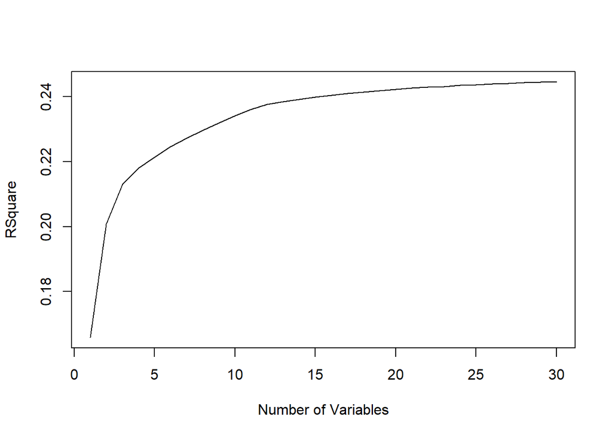

```r
#Code for Sales Representatives
dfTrain$JobRole <- ifelse(dfTrain$JobRole == "Sales Representative", 1, ifelse(dfTrain$JobRole == "Laboratory Technician", 0, 99))
dfTrain$JobRole <- as.factor(dfTrain$JobRole)

regfit.full.jr = regsubsets(JobRole ~ ., dfTrain, nvmax = 30)
reg.summary.jr <- summary(regfit.full.jr)
plot(reg.summary.jr$rsq,xlab = "Number of Variables", ylab = "RSquare", type = "l")
```

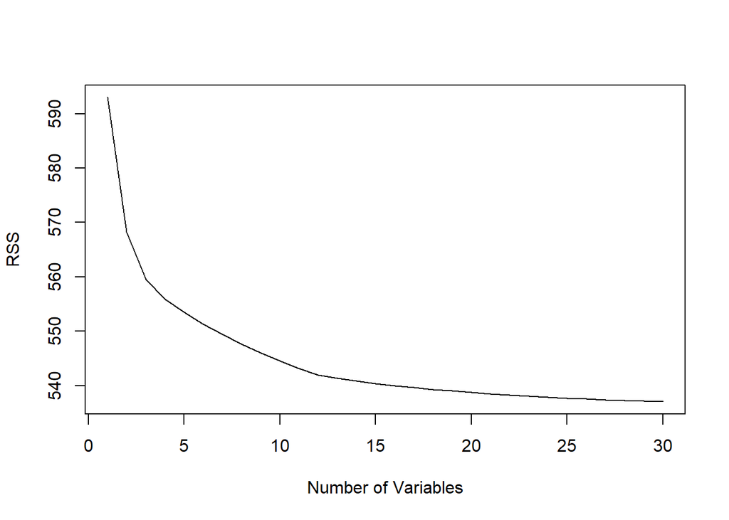

```r
plot(reg.summary.jr$rss,xlab = "Number of Variables", ylab = "RSS", type = "l")
```

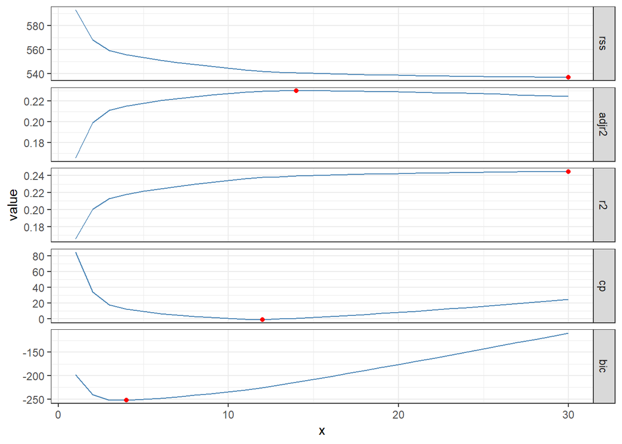

```r
## get best performing models according to each measure
jr.ind.rss <- which.min(reg.summary.jr$rss)
jr.val.rss <- reg.summary.jr$rss[jr.ind.rss]
jr.ind.adjr2 <- which.max(reg.summary.jr$adjr2)
jr.val.adjr2 <- reg.summary.jr$adjr2[jr.ind.adjr2]
jr.ind.r2 <- which.max(reg.summary.jr$rsq)
jr.val.r2 <- reg.summary.jr$rsq[jr.ind.r2]
jr.ind.cp <- which.min(reg.summary.jr$cp)
jr.val.cp <- reg.summary.jr$cp[jr.ind.cp]
jr.ind.bic <- which.min(reg.summary.jr$bic)
jr.val.bic <- reg.summary.jr$bic[jr.ind.bic]


fit.models.jr <- data.frame(x = 1:30, rss = reg.summary.jr$rss, adjr2 = reg.summary.jr$adjr2,
                         r2 = reg.summary.jr$rsq, cp = reg.summary.jr$cp, bic = reg.summary.jr$bic)
fit.models.jr <- melt(fit.models.jr, id.vars = 'x')

best.vals  <- data.frame(variable = unique(fit.models$variable),
                         inds = c(jr.ind.rss, jr.ind.adjr2, jr.ind.r2, jr.ind.cp, jr.ind.bic),
                         vals = c(jr.val.rss, jr.val.adjr2, jr.val.r2, jr.val.cp, jr.val.bic))

ggplot(data = fit.models.jr, aes(x = x, y = value)) + geom_line(color = 'steelblue') +
  geom_point(data = best.vals, aes(x = inds, y = vals),color = 'red') +
  facet_grid(variable ~., scales="free_y") + theme_bw()
```

```r
#Selected Variables
coef(regfit.full.jr,5)
```

```
##                      (Intercept)                        Attrition
##                        2.3971869                       -0.2802257
## DepartmentResearch & Development                         JobLevel
##                       -0.3301426                        0.2577200
##                      OverTimeYes            TrainingTimesLastYear
##                        0.1033425                       -0.0403120
```

```r
#build model
lm1.jr = glm(JobRole ~ Attrition + Department + JobLevel + OverTime + TrainingTimesLastYear, data = dfTrain, family = binomial(link = 'logit'))

summary(lm1.jr)
```

```
##
## Call:
## glm(formula = JobRole ~ Attrition + Department + JobLevel + OverTime +
##     TrainingTimesLastYear, family = binomial(link = "logit"),
##     data = dfTrain)
##
## Deviance Residuals:
##      Min        1Q    Median        3Q       Max
## -2.49395   0.00003   0.00017   0.59006   1.57405
##
## Coefficients:
##                                    Estimate Std. Error z value Pr(>|z|)
## (Intercept)                        17.84242 1389.60884   0.013 0.989756
## Attrition                          -0.84410    0.24999  -3.377 0.000734
## DepartmentResearch & Development  -18.68305 1389.60881  -0.013 0.989273
## DepartmentSales                    -0.38407 1484.54468   0.000 0.999794
## JobLevel                            1.40435    0.15438   9.097  < 2e-16
## OverTimeYes                         0.51889    0.21893   2.370 0.017784
## TrainingTimesLastYear              -0.15408    0.06735  -2.288 0.022157
##
## (Intercept)
## Attrition                        ***
## DepartmentResearch & Development
## DepartmentSales
## JobLevel                         ***
## OverTimeYes                      *
## TrainingTimesLastYear            *
## ---
## Signif. codes:  0 '***' 0.001 '**' 0.01 '*' 0.05 '.' 0.1 ' ' 1
##
## (Dispersion parameter for binomial family taken to be 1)
##
##     Null deviance: 1110.31  on 1169  degrees of freedom
## Residual deviance:  728.22  on 1163  degrees of freedom
## AIC: 742.22
##
## Number of Fisher Scoring iterations: 18
```

Based on the output, we can see job level, over time, and training times last year all are statistically significant variables in trying to distinguish these two groups from each other. Futher research would be recommended to try and figure out more about these variables and in order to gain a better undestanding since it is clear that only overtime is the variable that has a major impact also on attrition.